# Dagibatran Chrono

Equipe 9

2024-02-24

# Dabigatran Chrono :

On commence par charger les données et afficher le nuage de point :

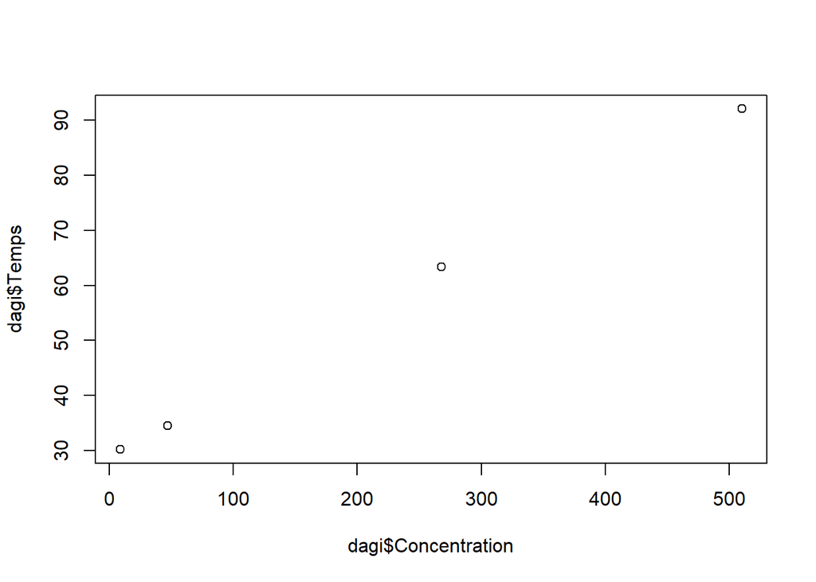

```r
dagi = read.csv2("data/etalonnage_dagi.csv", sep = ";")

plot(x=dagi$Concentration, y=dagi$Temps)
```

Les points semblent alignés ce qui suggère une relation linéaire nous procédons donc à une régression linéaire :

```r
modele <- lm(dagi$Temps ~ dagi$Concentration)

summary(modele)
```

```
##
## Call:
## lm(formula = dagi$Temps ~ dagi$Concentration)
##
## Residuals:
##        1        2        3        4
## -0.03298 -0.46003  0.94843 -0.45542
##
## Coefficients:
##                     Estimate Std. Error t value Pr(>|t|)
## (Intercept)        29.113419   0.586403   49.65 0.000405 ***
## dagi$Concentration  0.124396   0.002029   61.32 0.000266 ***
## ---
## Signif. codes:  0 '***' 0.001 '**' 0.01 '*' 0.05 '.' 0.1 ' ' 1
##
## Residual standard error: 0.8123 on 2 degrees of freedom
## Multiple R-squared:  0.9995, Adjusted R-squared:  0.9992
## F-statistic:  3760 on 1 and 2 DF,  p-value: 0.0002659
```

Les coefficients de la régression sont significatifs au seuil de 1%, le R carré est proche de 1.

Notons que la p-value associée au coefficient correspondant à la pente de la droite de régression nous indique que la probabilité que ce coefficient soit négatif est inférieure à 3/1000. Nous considérons cette probabilité comme négligeable ce qui nous permettra de construire nos intervalles de confiances.

Tous les indicateurs semblent confirmer une relation linéaire entre concentration et temps. Ce qui se confirme grapiquement :

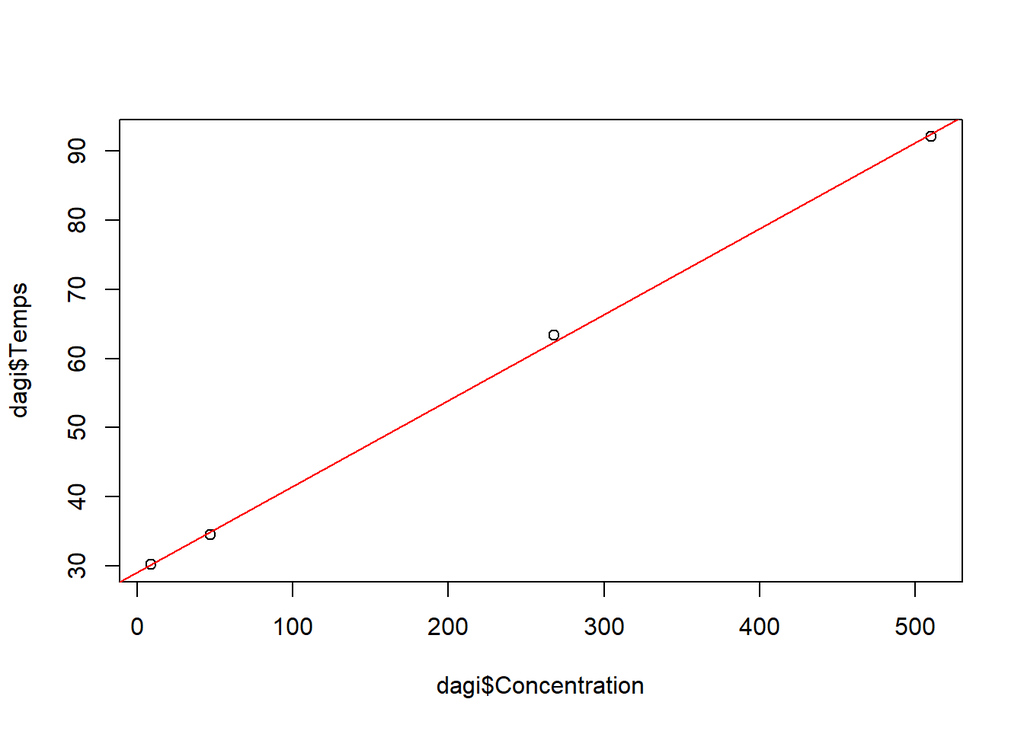

```r
plot(x=dagi$Concentration, y=dagi$Temps)
abline(modele, col = "red")
```

Voyons ce que donne une analyse des résidus :

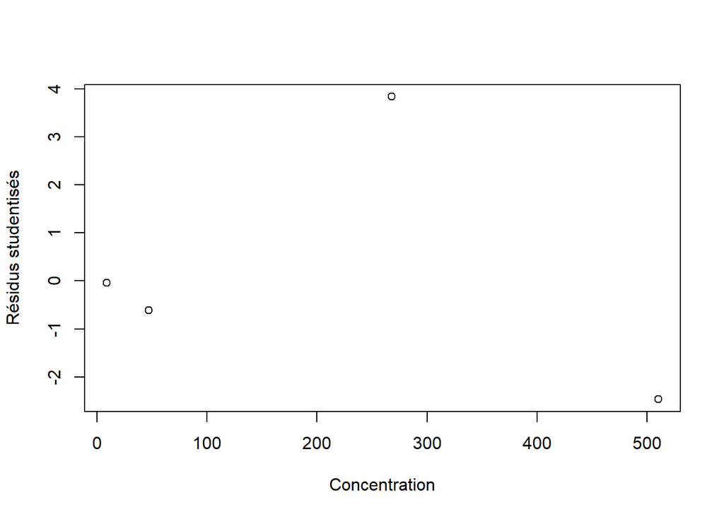

```r
res <- rstudent(modele)
plot(dagi$Concentration,res,xlab="Concentration", ylab="Résidus studentisés")
```

Avec seulement quatre points, il est difficile d’analyser ces résidus. Toutefois, il pourrait apparaître qu’ils soient croissants avec la concentration ce qui pourrait remettre en cause l’hypothèse d’homoscédasticité. Nous y reviendrons plus tard.

## limite de blanc

### en utilisant des mesures dédiées

Commençons par charger et observer les mesures de blanc à notre disposition :

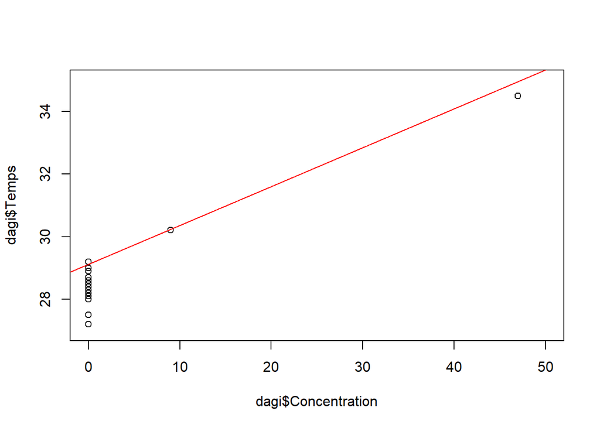

```r
blancs <- read.csv2("data/blancDabitranChrono.csv", sep = ";")

plot(x=dagi$Concentration, y=dagi$Temps, ylim = c(27,35), xlim = c(0,50))
points(0*blancs$Temps, blancs$Temps)
abline(modele, col = "red")
```

On peut remarquer que la grande majorité des mesures de blanc est située sous la droite de régression, ce qui pourrait laisser envisager que la relation entre temps et concentration n’est pas linéaire au voisinage de 0. Une nouvelle fois avec seulement 4 points pour construire la droite de régression, il est difficile d’être affirmatif.

Testons la normalité de nos mesures de blanc :

```r
shapiro.test(blancs$Temps)
```

```
##
##  Shapiro-Wilk normality test
##
## data:  blancs$Temps
## W = 0.93299, p-value = 0.07336
```

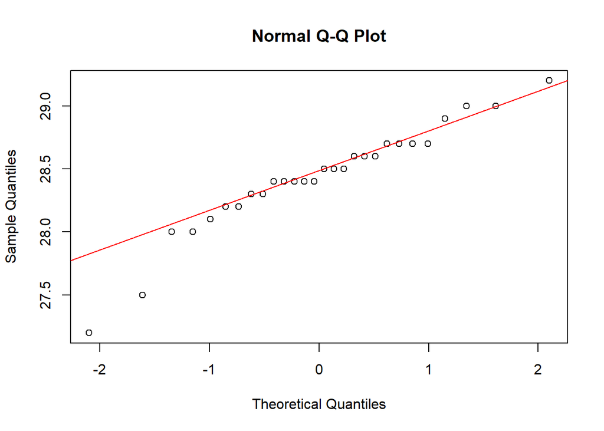

```r
qqnorm(blancs$Temps )
qqline(blancs$Temps, col='red')
```

Une première méthode pour calculer la limite de blanc est d’utiliser le quantile empirique. Dans toutes ce document nous considérons un niveau de confiance de 95% pour les calculs de limite de blanc et de détection et un niveau de confiance de 90% pour les limites de quantification.

```r
LOB<-(quantile(blancs$Temps, 0.95) - modele$coefficients[1])/modele$coefficients[2]
names(LOB) <- c("LOB")
LOB
```

```
##        LOB
## -0.9117595
```

On obtient ici une valeur négative ce qui provient du fait que l’essentiel des mesures de blanc sont situés sous la droite de régression.

Qu’en est-il lorsqu’on se place dans le modèle Gaussien :

```r
moyenne_b <- mean(blancs$Temps)
var_b <- var(blancs$Temps)
sigma_b <- sqrt(var_b)
n = 30
LOB1 <- (moyenne_b + qt(0.95, n - 1)*sigma_b*sqrt(1 + 1/n) - modele$coefficients[1])/modele$coefficients[2]
names(LOB1) <- c("LOB")
LOB1
```

```
##      LOB
## 0.383705
```

On constate que dans le cadre Gaussien la limite de blanc estimée est légèrement positive. Il est à noter que contrairement au quantile empirique, la limite de blanc calculée dans le cadre du modèle Gaussien n’est pas biaisée.

### à partir des données d’étalonnage.

Voyons ce que donne la limite de blanc calculée à partir des données d’étalonnage :

```r
X <- model.matrix(modele)
XTX <- t(X) %*% X
D <- det(XTX)
somme = sum(dagi$Concentration)
n <- 4
LOB2 <-  qt(0.95, n - 2)*sigma(modele)*sqrt(1 + 1/n + somme^2/n/D)/modele$coefficients[2]
names(LOB2) <- c("LOB")
LOB2
```

```
##     LOB
## 23.5166
```

Cette limite est très supérieure à celles calculées avec les mesures de blancs dédiées. Ceci s’explique par le fait que d’une part la courbe d’étalonnage est située au dessus de la plupart des mesures de blancs. D’autre part l’écart type résiduel de la régression (environ 0.8) est deux fois plus élevé que l’écart type des mesures de blancs (environ 0.4).

Lorsqu’on dispose de mesures de blancs, il est préférable de les utiliser pour calculer la limite de blanc. Dans la suite lorsque nous avons besoin d’une limite de blanc nous utiliserons celle calculée avec des mesures dédiés dans le cadre Gaussien.

## limite de détection

Procédons maintenant au calcul de la limite de détection.

```r
K <- (qt(0.05, n - 2)*sigma(modele)/modele$coefficients[2])^2
a <- 1 - K*n/D
b <- -2*(LOB1 -K*somme/D)
c <- LOB1^2 - K*(1+1/n + somme^2/n/D)
delta <- b^2 - 4*a*c
LOD <- (-b + sqrt(delta))/2/a
names(LOD) <- c("LOD")
LOD
```

```
##      LOD
## 23.45104
```

On peut remarquer que la limite de détection ainsi calculée est proche de la limite de blanc calculée avec les données d’étalonnage. Ce n’est pas complètement le fruit du hasard. La Limite de blanc que nous avons utilisé pour calculer la limite de détection est proche de 0. Ainsi, la limite de détection est à peu près égale à la demi longueur d’un intervalle de confiance à 90% de la mesure de la concentration. La longueur de cet intervalle varie certes en fonction de x, mais sa valeur en 0 (qui donne la limite de blanc par données d’étalonnage) reste proche de sa valeur au niveau de la limite de détection.

## limites de quantification

### précision absolue

Procédons au calcul des limites de quantification pour une précision absolue. Nous avons vu que la demi longueur de l’intervalle de confiance à 90% est d’environ 23.5 pour une concentration égale à 0. Elle est minimale pour une concentration égale à la moyenne des concentrations d’étalonnage avec une valeur d’environ 20. Nous allons choisir 22 comme précision cible.

```r
p <-22
a <- n/D
b <- -2*somme/D
c <- somme^2/n/D + 1 + 1/n - p^2/K
delta <- b^2 - 4*a*c
LOQ1 <- (-b - sqrt(delta))/2/a
LOQ2 <- (-b + sqrt(delta))/2/a
names(LOQ1) <- "LOQ1"
names(LOQ2) <- "LOQ2"
c(LOQ1,LOQ2)
```

```
##      LOQ1      LOQ2
##  94.34725 322.65275
```

La précision souhaitée sera obtenue pour des concentrations comprises entre 94 et 323.

### précision relative

Pour la précision relative nous allons nous fixer une précision de 15%. Si nous cherchons juste à ce que le coefficient de variation soit inférieur à cette valeur nous obtenons.

```r
#limite de quantification relative
r = 0.15
Kbis <- (sigma(modele)/modele$coefficients[2])^2
a <- n/D - r^2/Kbis
b <- -2*somme/D
c <- somme^2/n/D + 1 + 1/n
delta <- b^2 - 4*a*c
LOQ2 <- (-b - sqrt(delta))/2/a
LOQ1 <- (-b + sqrt(delta))/2/a
names(LOQ1) <- "LOQ1"
names(LOQ2) <- "LOQ2"
c(LOQ1,LOQ2)
```

```
##      LOQ1      LOQ2
## -56.56287  51.57481
```

La coefficient a étant négatif, la précision voulue sera obtenue à partir d’une concentration de 51.6. Ici nous n’avons pas d’estimation de la confiance associée à cette limite. Si l’on souhaite une précision de 15% avec un niveau de confiance de 90% il faut affiner le calcul :

```r
# à 95%
a <- n/D - r^2/K
b <- -2*somme/D
c <- somme^2/n/D + 1 + 1/n
delta <- b^2 - 4*a*c
LOQ2 <- (-b - sqrt(delta))/2/a
LOQ1 <- (-b + sqrt(delta))/2/a
names(LOQ1) <- "LOQ1"
names(LOQ2) <- "LOQ2"
c(LOQ1,LOQ2)
```

```
##      LOQ1      LOQ2
## -190.3420  143.6045
```

La limite ainsi obtenue (143.6) est très sensiblement supérieure à celle obtenue en se basant simplement sur le coefficient de variation.

## qualité des intervalles de confiance.

Pour construire nos intervalles de confiance nous avons négligé la probabilité que la pente de la droite de régressioin puisse prendre des valeurs négatives. Cela nous a permis de considérer qu’approximativement : $\frac{\hat{x}-x} {\frac{\sigma}{|\hat{\beta_{1}}|} \sqrt{1 + \frac{1}{n} + \frac{(nx - \sum_{i=1}^n x_i)^2}{nD} }} \sim \mathcal{N}(0,1)$. Nous allons vérifier à l’aide de simulations que cette approximation est justifiée pour x=0 et x=500 (valeurs minimale et maximale de la plage de concentration qui nous intéresse). Pour notre simulation nous utilisons les coefficients et variances estimées par la régression linéaire. Nous simulons 1 000 000 de réalisations indépendantes de $\frac{\hat{x}-x} {\frac{\sigma}{|\hat{\beta_{1}}|} \sqrt{1 + \frac{1}{n} + \frac{(nx - \sum_{i=1}^n x_i)^2}{nD} }}$ puis nous estimons à partir de ces simulations une liste de quantiles empiriques.

```r
simule_quantile <- function(x, modele, liste_quantiles ){
  set.seed(1234)
  X <- model.matrix(modele)
  XTX <- t(X) %*% X
  D <- det(XTX)
  somme = sum(X[,2])
  n < nrow(X)

  varbeta = sigma(modele)^2*solve(XTX)

  b0 = modele$coefficients[1]
  b1 = modele$coefficients[2]
  nb = 1000000 # nombre de simulation
  e1 = rnorm(nb)
  e2 = rnorm(nb)
  e3 = rnorm(nb)
  epsi = sigma(modele)*e1
  C = chol(varbeta) #décomposition de cholesky  pour simulation des coefficients
  b = cbind(e2,e3)%*%C
  b0_hat = b[,1] + b0
  b1_hat = b[,2] + b1

  x_hat = (b0 + b1*x + epsi - b0_hat)/b1_hat

  ma_stat  = abs(b1_hat)*(x_hat-x)/(sigma(modele)*sqrt(1 + 1/n + (n*x-somme)^2/n/D))

  return( quantile(ma_stat, liste_quantiles))

}
liste_quantiles <-c(0.001, 0.01, 0.025, 0.05, 0.1, 0.3, 0.5, 0.7,  0.9, 0.95, 0.975, 0.99, 0.999)
q0 <- simule_quantile(0, modele, liste_quantiles)
q500 <- simule_quantile(500, modele, liste_quantiles)
qnormal <- qnorm(liste_quantiles)

res = t(rbind(qnormal,q0, q0-qnormal, q500, q500-qnormal))
colnames(res) <- c("qnormal", "q0", "q0-qnormal", "q500", "q500-qnormal")
round(res, 5)
```

```
##        qnormal       q0 q0-qnormal     q500 q500-qnormal
## 0.1%  -3.09023 -3.08381    0.00642 -3.09975     -0.00952
## 1%    -2.32635 -2.32689   -0.00054 -2.32701     -0.00066
## 2.5%  -1.95996 -1.95843    0.00153 -1.96060     -0.00063
## 5%    -1.64485 -1.64601   -0.00115 -1.64361      0.00125
## 10%   -1.28155 -1.28108    0.00047 -1.27968      0.00187
## 30%   -0.52440 -0.52491   -0.00051 -0.52554     -0.00114
## 50%    0.00000  0.00084    0.00084  0.00004      0.00004
## 70%    0.52440  0.52546    0.00106  0.52398     -0.00042
## 90%    1.28155  1.28348    0.00193  1.28366      0.00211
## 95%    1.64485  1.64802    0.00316  1.64704      0.00219
## 97.5%  1.95996  1.96391    0.00395  1.96242      0.00245
## 99%    2.32635  2.33046    0.00411  2.32828      0.00194
## 99.9%  3.09023  3.09949    0.00925  3.09311      0.00288
```

Nous constatons que les quantiles issues des simulations s’écartent de moins de 0,01 des quantiles réels d’une loi normale centrée réduite. L’approximation est donc tout à fait acceptable.

# hétéroscédasticité 1

Lors de l’analyse des résidus de la régression linéaire nous avons évoqué le fait que la variance des résidus pourrait être fonction croissante de concentration. Nous avons été conforté dans cette hypothèse par le fait que l’écart type des mesures de blancs était environ deux fois moins élevé que la que l’écart type résiduelle de la régression.

Reprenons l’analyse en faisant l’hypothèse que la variance des résidus est proportionnelle à la concentration :

```r
#hétéroscedasticité :
y = dagi$Temps / sqrt(dagi$Concentration)
x1 = 1/sqrt(dagi$Concentration)
x2 = sqrt(dagi$Concentration)
modeleHet <-lm(y~x1+x2-1)
summary(modeleHet)
```

```
##
## Call:
## lm(formula = y ~ x1 + x2 - 1)
##
## Residuals:
##        1        2        3        4
##  0.01800 -0.05683  0.05635 -0.02599
##
## Coefficients:
##     Estimate Std. Error t value Pr(>|t|)
## x1 29.022525   0.176462  164.47  3.7e-05 ***
## x2  0.124832   0.002271   54.98 0.000331 ***
## ---
## Signif. codes:  0 '***' 0.001 '**' 0.01 '*' 0.05 '.' 0.1 ' ' 1
##
## Residual standard error: 0.06085 on 2 degrees of freedom
## Multiple R-squared:      1,  Adjusted R-squared:  0.9999
## F-statistic: 2.138e+04 on 2 and 2 DF,  p-value: 4.678e-05
```

Les coefficients obtenus sont sensiblement les mêmes, ils restent significatifs au seuil de 1%. Le R carré est encore plus élevé, tout proche de 1.

Voyons ce qu’il en est en terme de résidus :

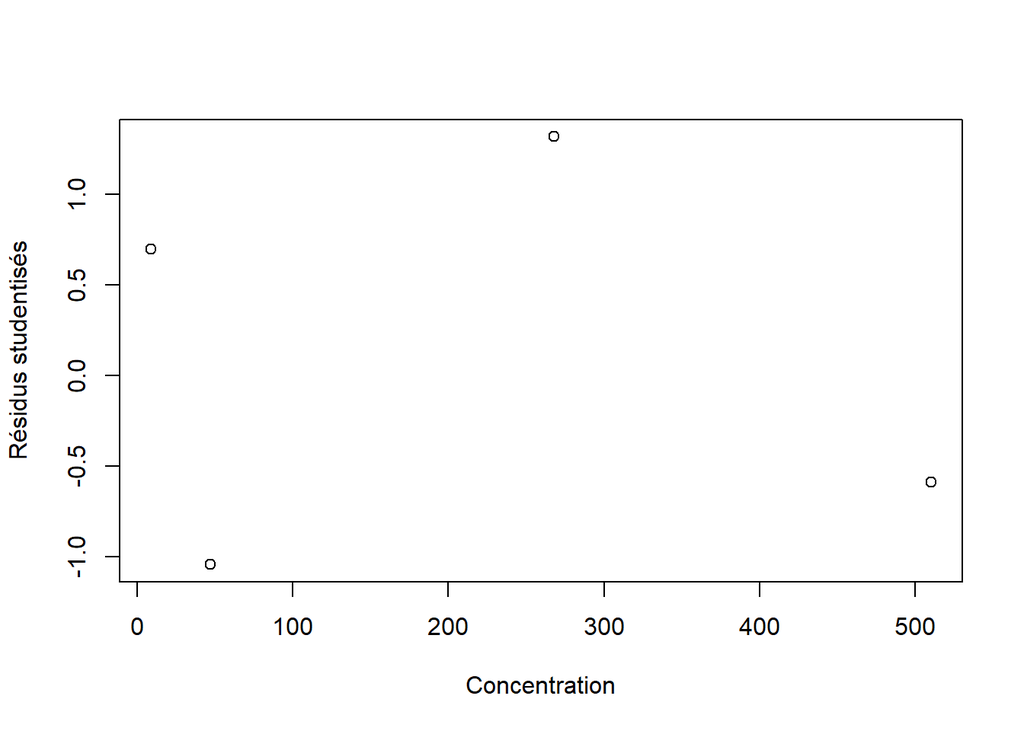

```r
res <- rstudent(modeleHet)
plot(dagi$Concentration,res,xlab="Concentration", ylab="Résidus studentisés")
```

Ici rien ne permet d’envisager une dépendance entre concentration et valeur des résidus.

Comment les limites sont-elles impactées par cette nouvelle modélisation ?

## limites de blancs

### avec mesures dédiées

Nous nous contenterons du calcul dans le cadre du modèle gaussien :

```r
n = 30
LOB_het1 <- (moyenne_b + qt(0.95, n - 1)*sigma_b*sqrt(1 + 1/n) - modeleHet$coefficients[1])/modeleHet$coefficients[2]
names(LOB_het1) <- "LOB"
LOB_het1
```

```
##      LOB
## 1.110498
```

Sans surprise, les coefficients obtenus par les deux régressions étant similaires, les limites de blanc obtenues à partir de mesures dédiées sont similaires.

### avec données d’étalonnage

```r
n <- 4
somme_inv = sum(1/dagi$Concentration)
X <- model.matrix(modeleHet)
XTX <- t(X) %*% X
D_het <- det(XTX)

K_het = (qt(0.05, n - 2)*sigma(modeleHet)/modeleHet$coefficients[2])^2

LOB_het2 = sqrt(K_het*(1/somme_inv + n^2/D_het/somme_inv))
names(LOB_het2) <- "LOB"
LOB_het2
```

```
##     LOB
## 4.12768
```

La limite de blanc ici obtenue est bien inférieure à celle obtenue dans le cas homoscédastique. Cela provient du fait qu’ici on ne prend en compte que l’incertitude sur les coefficients de la régression pour calculer cette limite. L’incertitude sur les temps associés aux mesures de blanc est par hytpothèse nulle contrairement à ce qui était le cas sous l’hypothèse d’homoscédasticité.

## limite de détection.

```r
a <- 1 - K_het*somme_inv/D_het
b <- -2*LOB_het1 -K_het*(1 -2*n/D_het)
c <- LOB_het1^2 - K_het*(1/somme_inv + n^2/somme_inv/D_het)
delta <- b^2 - 4*a*c
LOD <-(-b + sqrt(delta))/2/a
names(LOD) <- "LOD"
LOD
```

```
##      LOD
## 6.524142
```

On obtient une limite de détection sensiblement inférieure à celle obtenue dans le cas homoscédastique (23.5). Ceci est du au fait que la variance des résidus étant ici supposée proportionnelle aux concentrations, pour des concentrations falbles, elle est bien inférieure à celle calculée dans le cas homoscédastique.

## limites de quantification

### précision absolue

```r
#limites de
#absolu
p <- 22
a <- somme_inv/D_het
b <- 1 -2*n/D_het
c <- 1/somme_inv + n^2/somme_inv/D_het - p^2 /K_het
delta <- b^2 - 4*a*c
LOQ1 <- (-b - sqrt(delta))/2/a
LOQ2 <- (-b + sqrt(delta))/2/a
names(LOQ1) <- "LOQ1"
names(LOQ2) <- "LOQ2"
c(LOQ1,LOQ2)
```

```
##      LOQ1      LOQ2
## -854.0240  193.8365
```

### précision relative

```r
#relative
r <- 0.15
a <- somme_inv/D_het -r^2/K_het
b <- 1 -2*n/D_het
c <- 1/somme_inv + n^2/somme_inv/D_het
delta <- b^2 - 4*a*c
LOQ2 <- (-b - sqrt(delta))/2/a
LOQ1 <- (-b + sqrt(delta))/2/a
names(LOQ1) <- "LOQ1"
names(LOQ2) <- "LOQ2"
c(LOQ1,LOQ2)
```

```
##       LOQ1       LOQ2
##  -8.402772 103.034476
```

Le coefficient a étant négatif, la précision de 15% sera obtenue avec un niveau de confiance de 90% pour des concentrations supérieures à 103, ce qui est sensiblement inférieur à la valeur obtenue sous l’hypothèse d’homoscédasticité (143).

# hétéroscédasticité 2

L’hypothèse d’une variance résiduelle proportionnelle à la concentration est en fait peu réaliste. Elle implique notamment que les mesures de blanc soient d’une précision parfaite, ce qui n’est pas le cas. Plutôt que de considérer la variance proportionnelle à la concentration nous allons considérer qu’elle est constituée d’un terme constant auquel s’ajoute un terme proportionnel à la concentration. En d’autres termes, la variance dépend linéairement de la concentration : v = v0 + v1x. Pour estimer v0 nous allons tout simplement utiliser variance des mesures de blancs. Pour estimer v1, nous allons en plus utiliser la variance résiduelle obtenue lors de la régression linéaire sous hypothèse d’homoscédasticité. Nous allons considérer que cette variance est égale à la variance correspondant à une concentration égale à la moyenne des concentrations d’étalonnage.

```r
#hetéro linéaire
v0 = var(blancs$Temps)
v1 = (sigma(modele)^2 - v0)/somme*n
y = dagi$Temps / sqrt(v0 +v1*dagi$Concentration)
x1 = 1/sqrt(v0 + v1 * dagi$Concentration)
x2 = dagi$Concentration / sqrt(v0 + v1*dagi$Concentration)
modeleHet <-lm(y~x1+x2-1)
summary(modeleHet)
```

```
##
## Call:
## lm(formula = y ~ x1 + x2 - 1)
##
## Residuals:
##       1       2       3       4
##  0.2477 -0.6400  1.0144 -0.5784
##
## Coefficients:
##     Estimate Std. Error t value Pr(>|t|)
## x1 28.962994   0.349075   82.97 0.000145 ***
## x2  0.125118   0.002094   59.74 0.000280 ***
## ---
## Signif. codes:  0 '***' 0.001 '**' 0.01 '*' 0.05 '.' 0.1 ' ' 1
##
## Residual standard error: 0.9577 on 2 degrees of freedom
## Multiple R-squared:  0.9999, Adjusted R-squared:  0.9998
## F-statistic: 1.089e+04 on 2 and 2 DF,  p-value: 9.178e-05
```

Les coefficients obtenus restent très proche de ceux obtenus lors des deux régressions précédentes. Ils sont significatifs au seuil de 1% et le R carré reste très proche de 1. On peut noter que la variance résiduelle est proche de 1 cela montre que notre modèle n’est pas complètement farfelu. Si la variance respectait exactement la formule v = v0 + v1x, avec les v0 et v1 estimée, la variance résiduelle “réelle” serait égale à 1.

Concernant les résidus, rien de remarquable :

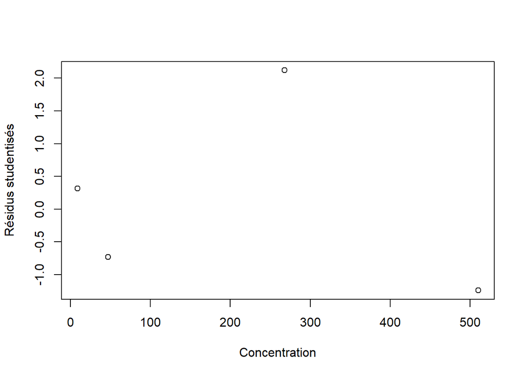

```r
res <- rstudent(modeleHet)
plot(dagi$Concentration,res,xlab="Concentration", ylab="Résidus studentisés")
```

Voyons comment évoluent les différentes limites.

## limites de blancs

### avec mesures dédiées

Nous nous contenterons du calcul dans le cadre du modèle gaussien :

```r
n = 30
LOB_het1 <- (moyenne_b + qt(0.95, n - 1)*sigma_b*sqrt(1 + 1/n) - modeleHet$coefficients[1])/modeleHet$coefficients[2]
names(LOB_het1) <- "LOB"
LOB_het1
```

```
##      LOB
## 1.583762
```

Les coefficients de la régressions étant proches de ceux obtenues dans les deux cas précécents, on retrouve une limite de blanc du même ordre de grandeur

## avec données d’étalonnage

```r
n <- 4
somme_inv = sum(1/(v0 +v1*dagi$Concentration))
X <- model.matrix(modeleHet)
XTX <- t(X) %*% X
D_het <- det(XTX)

K_het = (qt(0.05, n - 2)*sigma(modeleHet)/modeleHet$coefficients[2])^2

LOB_het = sqrt(K_het*(v0 + 1/somme_inv + n^2/D_het/somme_inv))
names(LOB_het) <- "LOB"
LOB_het
```

```
##      LOB
## 11.73394
```

La valeur obtenue est située entre les deux limites obtenues précédemment. Cela provient du fait que la variance pour des concentrations nulles est ici supérieure à 0, mais deux fois plus faible que celle obtenue sous hypothèse d’homoscédaticité.

## limite de détection

```r
a <- 1 - K_het*somme_inv/D_het
b <- -2*LOB_het1 -K_het*(v1 -2*n/D_het)
c <- LOB_het1^2 - K_het*(v0 + 1/somme_inv + n^2/somme_inv/D_het)
delta <- b^2 - 4*a*c
LOD <- (-b + sqrt(delta))/2/a
names(LOD) <- "LOD"
LOD
```

```
##      LOD
## 14.00275
```

La limite de détection obtenue est là encore située entre les deux limites précédemment calculées. Là encore cela provient d’une valeur intermédiaire en termes de variance.

## limites de quantification

### précision absolue

```r
#limites de
#absolu
p <- 22
a <- somme_inv/D_het
b <- v1 -2*n/D_het
c <- v0 + 1/somme_inv + n^2/somme_inv/D_het - p^2 /K_het
delta <- b^2 - 4*a*c
LOQ1 <- (-b - sqrt(delta))/2/a
LOQ2 <- (-b + sqrt(delta))/2/a
names(LOQ1) <- "LOQ1"
names(LOQ2) <- "LOQ2"
c(LOQ1,LOQ2)
```

```
##      LOQ1      LOQ2
## -690.5946  209.9337
```

### précision relative.

```r
#relative
r <- 0.15
a <- somme_inv/D_het -r^2/K_het
b <- v1 -2*n/D_het
c <- v0 + 1/somme_inv + n^2/somme_inv/D_het
delta <- b^2 - 4*a*c
LOQ2 <- (-b - sqrt(delta))/2/a
LOQ1 <- (-b + sqrt(delta))/2/a
names(LOQ1) <- "LOQ1"
names(LOQ2) <- "LOQ2"
c(LOQ1,LOQ2)
```

```
##      LOQ1      LOQ2
## -58.98194 116.07251
```

Le coefficient a étant négatif, la précision de 15% sera obtenue avec un niveau de confiance de 90% pour des concentrations supérieures à 116. Cette valeur est située entre les valeurs obtenues précédemment (103 sous hypothèse de variance proportionnelle à la concentration et 143 sous hypothèse d’homoscédasticité).

# Premier Bilan

Hormis les limites de blanc calculées avec des mesures dédiées, les limites calculées varient très significativement en fonction des hypothèses faites sur le lien entre variance résiduelle et concentration. Le faible nombre de données en notre possession de nous permet de privilégier sérieusement une hypothèse plutôt qu’une autre. Pour décider du calcul de limites le plus adéquat à mettre en place il faudrait disposer de nombreuses mesures effectuées sur la plage de concentration pour laquelle on veut pouvoir utiliser la courbe d’étalonnage.

# Etalonnage avec mesures de blancs

Jusqu’à maintenant nous avons d’une part construit une droite d’étalonnage sans aucune mesure de blanc, puis utilisé des mesures de blancs pour la construction de limites de blanc et de détection. Nous allons maintenant intégrer les mesures de blancs dans la construction de la courbe d’étalonnage

```r
dagic = rbind(data.frame(Concentration = dagi$Concentration, Temps = dagi$Temps), data.frame(rename(0*blancs, Concentration=Temps), blancs))
modelecomplet <- lm(dagic$Temps ~ dagic$Concentration)

summary(modelecomplet)
```

```
##
## Call:
## lm(formula = dagic$Temps ~ dagic$Concentration)
##
## Residuals:
##      Min       1Q   Median       3Q      Max
## -1.27249 -0.19749  0.02751  0.22751  1.16073
##
## Coefficients:
##                      Estimate Std. Error t value Pr(>|t|)
## (Intercept)         2.847e+01  8.843e-02   322.0   <2e-16 ***
## dagic$Concentration 1.260e-01  8.653e-04   145.6   <2e-16 ***
## ---
## Signif. codes:  0 '***' 0.001 '**' 0.01 '*' 0.05 '.' 0.1 ' ' 1
##
## Residual standard error: 0.4837 on 30 degrees of freedom
## Multiple R-squared:  0.9986, Adjusted R-squared:  0.9985
## F-statistic: 2.12e+04 on 1 and 30 DF,  p-value: < 2.2e-16
```

On peut noter que les coefficients restent significatif au seuil de 1%. Leur p-value est encore plus faible que dans les précédentes régressions effecutées. L’augmentation du nombre de mesures utilisées a mécaniquement diminué la variance des estimateurs des coefficients de la régression. En revanche, le R-carré ajusté, bien que très proche de 1 est un peu moins élevé que pour les régressions précédentes. On peut noter que la valeur de la constante est plus faible que précédemment et se rapproche de la valeur moyenne des blancs (28,43) et que la pente de la droite de régression a légèrement augmenté. L’écart type résiduelle quand à lui a presque été divisée par deux et s’approche de la valeur de l’écart type des blancs (0,42)

Voyons ce que donne une analyse des résidus :

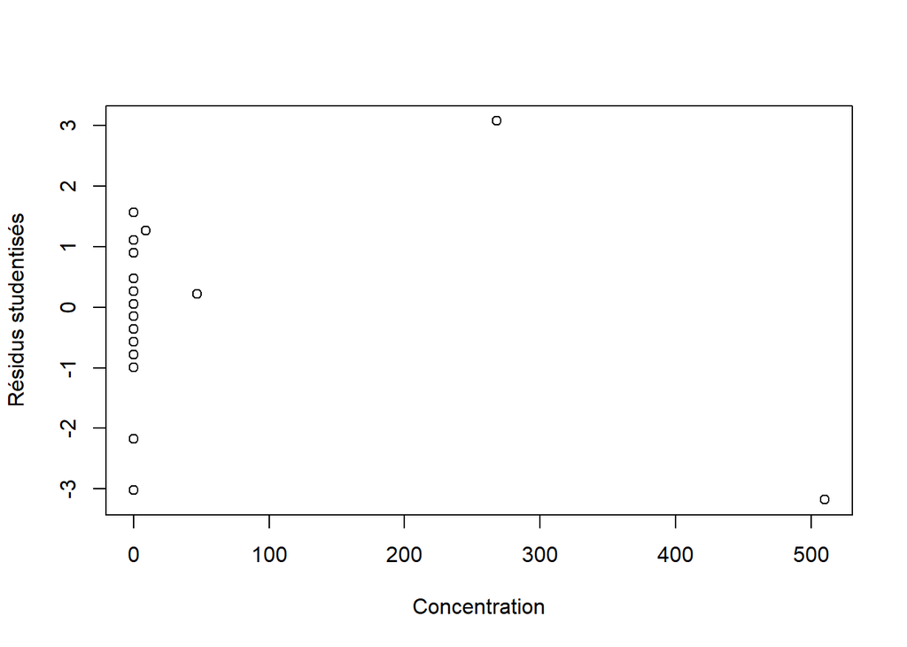

```r
res <- rstudent(modelecomplet)
plot(dagic$Concentration,res,xlab="Concentration", ylab="Résidus studentisés")
```

Une nouvelle fois, l’analyse des résidus est délicate, mais elle pourrait laisser entrevoir que la variance résiduelle soit une fonction croissante de la concentration.

## limite de blanc

### avec mesures dédiées :

Nous allons nous contenter de calculer la limite de blanc dans le cadre gaussien. Il est à noter qu’ici la courbe d’étalonnage dépend des mesures de blancs. Les mesures de blancs ne sont donc pas à proprement parle dédiées au calcul de la limite de blanc. On ne peut donc pas utiliser la courbe d’étalonnage pour transformer un quantile de mesure physique en quantile de mesure de blanc sans précaution. Cela nécessite de négliger le probalilité que l’estimation de a pente de la courbe soit négative. Probabilité qui est inférieure à $10^{-16}$ d’après le résultat de la régression linéaire.

```r
moyenne_b <- mean(blancs$Temps)
var_b <- var(blancs$Temps)
sigma_b <- sqrt(var_b)
n = 30
LOB1 <- (moyenne_b + qt(0.95, n - 1)*sigma_b*sqrt(1 + 1/n) - modelecomplet$coefficients[1])/modelecomplet$coefficients[2]
names(LOB1) <- "LOB"
LOB1
```

```
##      LOB
## 5.465728
```

On constate que la limite de blanc est ici sensiblement supérieure à celles estimées précédemment avec des mesures dédiées. Cela provient essentiellement de la baisse du l’estimation de la constante dans la régression linéaire.

### à partir des données d’étalonnage.

Voyons ce que donne la limite de blanc calculée à partir des données ayant servi à construire la courbe d’étalonnage:

```r
X <- model.matrix(modelecomplet)
XTX <- t(X) %*% X
D <- det(XTX)
somme = sum(dagic$Concentration)
n <- 34
LOB2 <-  qt(0.95, n - 2)*sigma(modelecomplet)*sqrt(1 + 1/n + somme^2/n/D)/modelecomplet$coefficients[2]
names(LOB2) <- "LOB"
LOB2
```

```
##      LOB
## 6.604408
```

La valeur de la limite de blanc calculéé ici est très proche de celles calculées à partir des mesures de blancs. Cela provient du fait que la valeur de la constante estimée par la régression est proche de la moyenne des blancs et du fait que la variance résiduelle de la régression est proche de la variance des mesures de blancs.

## limite de détection

Procédons maintenant au calcul de la limite de détection.

```r
K <- (qt(0.05, n - 2)*sigma(modelecomplet)/modelecomplet$coefficients[2])^2
a <- 1 - K*n/D
b <- -2*(LOB1 -K*somme/D)
c <- LOB1^2 - K*(1+1/n + somme^2/n/D)
delta <- b^2 - 4*a*c
LOD <- (-b + sqrt(delta))/2/a
names(LOD)<-"LOD"
LOD
```

```
##      LOD
## 12.06528
```

## limites de quantification :

### précision absolue :

Procédons au calcul des limites de quantification pour une précision absolue de 22 avec un seuil de 90%

```r
p <-22
a <- n/D
b <- -2*somme/D
c <- somme^2/n/D + 1 + 1/n - p^2/K
delta <- b^2 - 4*a*c
LOQ1 <- (-b - sqrt(delta))/2/a
LOQ2 <- (-b + sqrt(delta))/2/a
names(LOQ1) <- "LOQ1"
names(LOQ2) <- "LOQ2"
c(LOQ1,LOQ2)
```

```
##      LOQ1      LOQ2
## -1725.697  1774.756
```

La plage de concentration permettant d’obtenir la précision voulue est passée de [94, 323] à [0, 1775]. A nouveau cela est essentiellement du à la baisse de la variance résiduelle et des variances des estimateurs des coefficients de la régression.

### précision relative :

Pour la précision relative nous allons nous fixer une précision de 15% et un niveau de confiance de 90%.

```r
# à 90%
a <- n/D - r^2/K
b <- -2*somme/D
c <- somme^2/n/D + 1 + 1/n
delta <- b^2 - 4*a*c
LOQ2 <- (-b - sqrt(delta))/2/a
LOQ1 <- (-b + sqrt(delta))/2/a
names(LOQ1) <- "LOQ1"
names(LOQ2) <- "LOQ2"
c(LOQ1,LOQ2)
```

```
##      LOQ1      LOQ2
## -44.32880  44.01327
```

La précision relative voulue sera obtenue pour des concentrations supérieures à 44. La limite ainsi obtenue est très sensiblement inférieure à celle sous l’hypothèse d’homoscédasticité sans utilisé les mesures de blancs pour la construction de la courbe d’étalonnage (144). Une nouvelle fois de plus, c’est la baisse de de la variance résiduelle et la baisse de la variance des coefficients de la régression qui sont les causes principales de cet écart.

# Deuxième Bilan

Il semblerait que le fait d’utiliser les mesures de blancs pour construire la courbe d’étalonage permette d’améliorer la précision des mesures. Mais ce résultat est à prendre avec du recul. Il est obtenu sous une hypothèse contestable d’homoscédasticité. Sous cette hypothèse la présence de nombreuses mesures de blanc peut avoir pour effet de diminuer artificiellement la variance résiduelle. D’autre part le fait d’augmenter le nombre de mesures utilisés pour construire la droite d’étalonnage réduit mécaniquement la variance des coefficients calculées. Ce n’est pas pour autant l’assurance d’une amélioration de la qualité de l’ajustement linéaire. Il serait préférable d’augmenter le nombre de mesure en les répartissants sur l’ensemble de la plage de concentration que l’on souhaite pouvoir mesurer.